# ordinal regression model

Dr.metales

12/25/2019

## Introduction

In this paper we will fit several models to the **heart disease** data [uploaded from kaggle website](https://www.kaggle.com/johnsmith88/heart-disease-dataset). You can also download this data directly from the html output of this rmarkdown file to nay format you want (at least the formats listed above the table).

## Data praparation

First, we call the data and the libraries that we need along this illustration as follows.

```r
library(tidyverse)
library(caret)
mydata<-read.csv("heart.csv",header = TRUE)
names(mydata)[1]<-"age"
```

The data at hand has the following features:

- age.
- sex: 1=male,0=female
- cp : chest pain type.
- trestbps : resting blood pressure.
- chol: serum cholestoral.
- fbs : fasting blood sugar.
- restecg : resting electrocardiographic results.
- thalach : maximum heart rate achieved
- exang : exercise induced angina.
- oldpeak : ST depression induced by exercise relative to rest.
- slope : the slope of the peak exercise ST segment.
- ca : number of major vessels colored by flourosopy.
- thal : it is not well defined from the data source.
- target: have heart disease or not.

```r
creat_dt <- function(x){
  DT::datatable(x,
                extensions = "Buttons",
                options = list(dom="Blfrtip",
                buttons=c("copy","csv","excel","pdf","print"),
                lengthMenu=list(c(10,25,50,-1),
                                c(10,25,50,"All")

                )
                ))
}

creat_dt(mydata)
```

|  | age | sex | cp | trestbps | chol | fbs | restecg | thalach | exang | oldpeak | slope | ca | thal | target |
| --- | --- | --- | --- | --- | --- | --- | --- | --- | --- | --- | --- | --- | --- | --- |
| 1 | 63 | 1 | 3 | 145 | 233 | 1 | 0 | 150 | 0 | 2.3 | 0 | 0 | 1 | 1 |
| 2 | 37 | 1 | 2 | 130 | 250 | 0 | 1 | 187 | 0 | 3.5 | 0 | 0 | 2 | 1 |
| 3 | 41 | 0 | 1 | 130 | 204 | 0 | 0 | 172 | 0 | 1.4 | 2 | 0 | 2 | 1 |
| 4 | 56 | 1 | 1 | 120 | 236 | 0 | 1 | 178 | 0 | 0.8 | 2 | 0 | 2 | 1 |
| 5 | 57 | 0 | 0 | 120 | 354 | 0 | 1 | 163 | 1 | 0.6 | 2 | 0 | 2 | 1 |
| 6 | 57 | 1 | 0 | 140 | 192 | 0 | 1 | 148 | 0 | 0.4 | 1 | 0 | 1 | 1 |
| 7 | 56 | 0 | 1 | 140 | 294 | 0 | 0 | 153 | 0 | 1.3 | 1 | 0 | 2 | 1 |
| 8 | 44 | 1 | 1 | 120 | 263 | 0 | 1 | 173 | 0 | 0 | 2 | 0 | 3 | 1 |
| 9 | 52 | 1 | 2 | 172 | 199 | 1 | 1 | 162 | 0 | 0.5 | 2 | 0 | 3 | 1 |
| 10 | 57 | 1 | 2 | 150 | 168 | 0 | 1 | 174 | 0 | 1.6 | 2 | 0 | 2 | 1 |

[output cut: 293 more lines]

For our case we will use the chest pain type **cp** variable as our target variable since it is a categorical variable. However, for pedagogique purposes, we will manipulate it so that it will be an ordered factor with only three levels **no pain**,**moderate pain**, **severe pain** (instead of 4 levels now).

First, we convert the variables that chould be of factor type, next we drop the the less frequently level from the **cp** variable and all the related rows, then we rename its lavels as **no** pain for the most frequently one, **severe** pain for the less frequently one, and **moderate** pain for the last one.

Now let’s include all the predictors except those factors that do not satisfy the threshold of 5 cases in the cross tables, and we remove the **cp level** “3” as we did earlier.

```r
mydata<-mydata %>%
  modify_at(c(2,3,6,7,9,11,12,13,14),as.factor)
mydata<-mydata[mydata$cp!=3,]
mydata$cp<-fct_drop(mydata$cp,only=levels(mydata$cp))
table(mydata$cp)
```

```
##
##   0   1   2
## 143  50  87
```

According to these frequencies we rename and we order the levels as follows.

```r
mydata$cp<-fct_recode(mydata$cp,no="0",sev="1",mod="2")
mydata$cp<-factor(mydata$cp,ordered = TRUE)
mydata$cp<-fct_infreq(mydata$cp)
mydata$cp[1:5]
```

```
## [1] mod sev sev no  no
## Levels: no < mod < sev
```

Similar to the logistic regression, the number of cases in each cell from each cross table between the outcome and each factor should be above the threshold of 5 applied in practice.

```r
xtabs(~cp+sex,data=mydata)
```

```
##      sex
## cp      0   1
##   no   39 104
##   mod  35  52
##   sev  18  32
```

```r
xtabs(~cp+target,data=mydata)
```

```
##      target
## cp      0   1
##   no  104  39
##   mod  18  69
##   sev   9  41
```

```r
xtabs(~cp+fbs,data=mydata)
```

```
##      fbs
## cp      0   1
##   no  125  18
##   mod  70  17
##   sev  45   5
```

```r
xtabs(~cp+restecg,data=mydata)
```

```
##      restecg
## cp     0  1  2
##   no  78 62  3
##   mod 36 50  1
##   sev 19 31  0
```

```r
xtabs(~cp+exang,data=mydata)
```

```
##      exang
## cp     0  1
##   no  63 80
##   mod 76 11
##   sev 46  4
```

```r
xtabs(~cp+slope,data=mydata)
```

```
##      slope
## cp     0  1  2
##   no  11 84 48
##   mod  5 33 49
##   sev  2 12 36
```

```r
xtabs(~cp+ca,data=mydata)
```

```
##      ca
## cp     0  1  2  3  4
##   no  65 34 29 14  1
##   mod 57 20  2  5  3
##   sev 37  8  3  1  1
```

```r
xtabs(~cp+thal,data=mydata)
```

```
##      thal
## cp     0  1  2  3
##   no   1 12 52 78
##   mod  1  2 62 22
##   sev  0  2 39  9
```

The following variables do not respect this threshold nad hence they will be removed from the predictors set: **restecg**, **exang**, **slope**, **ca**, and **thal**.

```r
mydata<-mydata[,-c(7,9,11,12,13)]
```

Now let’s partition the data and train the model.

```r
set.seed(1122)
index<-createDataPartition(mydata$cp,p=.8,list=FALSE)
train<-mydata[index,]
test<-mydata[-index,]
```

## ordered logistic regression:

Before training this type of model let’s show how it works. For simplicity suppose we have data that has an ordered outcome $y$ with three classe labels (“1”,“2”,“3”) and only two features $x_1$ and $x_2$.

First we define a latent variable as a linear combination of the features:

$$y_i^*=\beta_1 X_{i1}+\beta_2 X_{i2}$$

Then since we have three classes we define two thresholds for this latent variable $\alpha_1$ and $\alpha_2$ , and a particular observation will be classified $y_i$ will be classified as follows:

$$\begin{cases} y_i=1 & \text{if $y_i^* \leq \alpha_1$} \\
y_i=2 & \text{if $\alpha_1 < y_i^* \leq \alpha_2$} \\
y_i=3 & \text{if $y_i^* > \alpha_2$}\end{cases}$$

Now we can obtain the probability of a particular observation to fall into a specific class as follows:

$$\begin{cases} p(y_i=1)=p(y_i^* \leq \alpha_1)=F(\alpha_1-\beta_1 X_{i1}-\beta_2 X_{i2}) \\
p(y_i=2)=p(\alpha_1 < y_i^* \leq \alpha_2)=F(\alpha_2-\beta_1 X_{i1}-\beta_2 X_{i2})-F(\alpha_1-\beta_1 X_{i1}-\beta_2 X_{i2}) \\
p(y_i=3)=1-p(y_i=2)-p(y_i=1)\end{cases}$$

It reamins now to define the suitable distribution function F. There are two commonly used ones for this type of data, the **logit** function $F(x)=\frac{1}{1+exp^{-x}}$ and the the normal distribution function aka **probit**.

Using the **logit** function the probabilities will be.

$$\begin{cases} p(y_i=1)=\frac{1}{1+exp^{-(\alpha_1-\beta_1 X_{i1}-\beta_2 X_{i2})}} \\
p(y_i=2)=\frac{1}{1+exp^{-(\alpha_2-\beta_1 X_{i1}-\beta_2 X_{i2})}}-p(y_i=1) \\
p(y_i=3)=1-p(y_i=2)-p(y_i=1)\end{cases}$$

```r
library(MASS)
set.seed(1234)
model_logistic<-train(cp~., data=train,
                      method="polr",
                      tuneGrid=expand.grid(method="logistic"))
```

```r
summary(model_logistic)
```

```
##
## Coefficients:
##               Value Std. Error t value
## age       0.0300328   0.018507  1.6228
## sex1      0.2824922   0.313882  0.9000
## trestbps  0.0017017   0.008944  0.1903
## chol     -0.0004838   0.003163 -0.1529
## fbs1     -0.0428962   0.414521 -0.1035
## thalach   0.0293075   0.008650  3.3881
## oldpeak  -0.3520267   0.167613 -2.1002
## target1   1.7109938   0.363500  4.7070
##
## Intercepts:
##         Value   Std. Error t value
## no|mod   7.0053  2.1270     3.2935
## mod|sev  8.9468  2.1608     4.1406
##
## Residual Deviance: 371.658
## AIC: 391.658
```

To get the significance we can and the p_values as follows.

```r
prob <- pnorm(abs(summary(model_logistic)$coefficients[,3]),lower.tail = FALSE)*2
cbind(summary(model_logistic)$coefficients,prob)
```

```
##                  Value  Std. Error    t value         prob
## age       0.0300328284 0.018506835  1.6227966 1.046329e-01
## sex1      0.2824922102 0.313881691  0.8999958 3.681225e-01
## trestbps  0.0017016693 0.008944194  0.1902541 8.491101e-01
## chol     -0.0004837763 0.003162975 -0.1529498 8.784379e-01
## fbs1     -0.0428962455 0.414521072 -0.1034839 9.175789e-01
## thalach   0.0293074859 0.008650063  3.3881242 7.037240e-04
## oldpeak  -0.3520266855 0.167612899 -2.1002362 3.570806e-02
## target1   1.7109938448 0.363500421  4.7069927 2.513979e-06
## no|mod    7.0052741842 2.126970789  3.2935451 9.893247e-04
## mod|sev   8.9467560381 2.160764017  4.1405521 3.464709e-05
```

Using the p values we will remove the non significant variables. **age**, **trestbps**, **chol**.

```r
set.seed(1234)
model_logistic<-train(cp~.-age-trestbps-chol, data=train,
                      method="polr",tuneGrid=expand.grid(method="logistic"))
prob <- pnorm(abs(summary(model_logistic)$coefficients[,3]),lower.tail = FALSE)*2
cbind(summary(model_logistic)$coefficients,prob)
```

```
##               Value  Std. Error    t value         prob
## sex1     0.21432042 0.301364580  0.7111666 4.769810e-01
## fbs1     0.08957113 0.399283317  0.2243298 8.225007e-01
## thalach  0.02369858 0.007690663  3.0814746 2.059781e-03
## oldpeak -0.32957841 0.164944471 -1.9981173 4.570394e-02
## target1  1.64549079 0.356352234  4.6175964 3.882104e-06
## no|mod   4.38444720 1.190808237  3.6819087 2.314943e-04
## mod|sev  6.31623474 1.234080702  5.1181699 3.085146e-07
```

Notice that we do not remove the factors **sex** and **fbs** even they are not significant due to the significance of the intercepts.

To well explain these coefficients lets restrict the model with only two predictors.

```r
set.seed(1234)
model1<-train(cp~target+thalach,
              data=train,
              method = "polr",
              tuneGrid=expand.grid(method="logistic"))
summary(model1)
```

```
##
## Coefficients:
##           Value Std. Error t value
## target1 1.82179   0.325618   5.595
## thalach 0.02717   0.007563   3.593
##
## Intercepts:
##         Value  Std. Error t value
## no|mod  5.1590 1.1202     4.6056
## mod|sev 7.0698 1.1699     6.0428
##
## Residual Deviance: 379.4938
## AIC: 387.4938
```

Let’s plug in these coefficients in the above equations we obtain the probability of each class as follows:

$$\begin{cases} p(no)=\frac{1}{1+exp^{-(5.1590-1.82179X_{i1}-0.02717X_{i2})}} \\
p(mod)=\frac{1}{1+exp^{-(7.0698 -1.82179X_{i1}-0.02717X_{i2})}}-p(no) \\
p(sev)=1-p(mod)-p(no)\end{cases}$$

Let’s predict a particular patient.

```r
train[3,c("cp","thalach","target")]
```

```
##   cp thalach target
## 5 no     163      1
```

$$\begin{cases} p(no)=\frac{1}{1+exp^{-(5.1590-1.82179X_{i1}-0.02717X_{i2})}} \\
p(mod)=\frac{1}{1+exp^{-(7.0698-1.82179X_{i1}-0.02717X_{i2})}}-p(no) \\
p(sev)=1-p(mod)-p(no)\end{cases}$$

```r
1/(1+exp(-(5.1590-1.82179*1-0.02717*163)))
```

```
## [1] 0.2513359
```

```r
1/(1+exp(-(7.0698-1.82179*1-0.02717*163)))
```

```
## [1] 0.6940877
```

$$\begin{cases} p(no)=0.2513359 \\
p(mod)=0.6940877-0.2513359=0.4427518 \\
p(sev)=1-0.4427518-0.2513359=0.3059123\end{cases}$$

```r
predict(model1,train[1:3,], type="prob")
```

```
##          no       mod       sev
## 2 0.1488216 0.3928046 0.4583738
## 4 0.1825255 0.4189064 0.3985681
## 5 0.2512875 0.4427381 0.3059744
```

Now lets get the confusion matrix for the training set.

```r
pred<-predict(model_logistic,newdata = train)
confusionMatrix(pred,train$cp)
```

```
## Confusion Matrix and Statistics
##
##           Reference
## Prediction no mod sev
##        no  91  20   8
##        mod 21  45  28
##        sev  3   5   4
##
## Overall Statistics
##
##                Accuracy : 0.6222
##                  95% CI : (0.5554, 0.6858)
##     No Information Rate : 0.5111
##     P-Value [Acc > NIR] : 0.0005112
##
##                   Kappa : 0.3599
##
##  Mcnemar's Test P-Value : 0.0003765
##
## Statistics by Class:
##
##                      Class: no Class: mod Class: sev
## Sensitivity             0.7913     0.6429    0.10000
## Specificity             0.7455     0.6839    0.95676
## Pos Pred Value          0.7647     0.4787    0.33333
## Neg Pred Value          0.7736     0.8092    0.83099
## Prevalence              0.5111     0.3111    0.17778
## Detection Rate          0.4044     0.2000    0.01778
## Detection Prevalence    0.5289     0.4178    0.05333
## Balanced Accuracy       0.7684     0.6634    0.52838
```

Th eaccuracy rate of the training set is about 62%.

For the test set now.

```r
pred<-predict(model_logistic,newdata = test)
confusionMatrix(pred,test$cp)
```

```
## Confusion Matrix and Statistics
##
##           Reference
## Prediction no mod sev
##        no  23   5   1
##        mod  3   9   7
##        sev  2   3   2
##
## Overall Statistics
##
##                Accuracy : 0.6182
##                  95% CI : (0.4773, 0.7459)
##     No Information Rate : 0.5091
##     P-Value [Acc > NIR] : 0.06848
##
##                   Kappa : 0.3654
##
##  Mcnemar's Test P-Value : 0.48746
##
## Statistics by Class:
##
##                      Class: no Class: mod Class: sev
## Sensitivity             0.8214     0.5294    0.20000
## Specificity             0.7778     0.7368    0.88889
## Pos Pred Value          0.7931     0.4737    0.28571
## Neg Pred Value          0.8077     0.7778    0.83333
## Prevalence              0.5091     0.3091    0.18182
## Detection Rate          0.4182     0.1636    0.03636
## Detection Prevalence    0.5273     0.3455    0.12727
## Balanced Accuracy       0.7996     0.6331    0.54444
```

The accuracy rate is about 61.82%

## CART model

This is tree-based model. To train this model we make use of **rpartScore** package, and for simplification we will include only the significant predictors from the previous model.

```r
library(rpartScore)
set.seed(1234)
model_cart<-train(cp~.-age-trestbps-chol, data=train,
                      method="rpartScore")
```

```r
model_cart
```

```
## CART or Ordinal Responses
##
## 225 samples
##   8 predictor
##   3 classes: 'no', 'mod', 'sev'
##
## No pre-processing
## Resampling: Bootstrapped (25 reps)
## Summary of sample sizes: 225, 225, 225, 225, 225, 225, ...
## Resampling results across tuning parameters:
##
##   cp          split  prune  Accuracy   Kappa
##   0.01818182  abs    mr     0.5479195  0.2414068
##   0.01818182  abs    mc     0.5670058  0.2770549
##   0.01818182  quad   mr     0.5600354  0.2551736
##   0.01818182  quad   mc     0.5683146  0.2726210
##   0.02121212  abs    mr     0.5508718  0.2446449
##   0.02121212  abs    mc     0.5711729  0.2803401
##   0.02121212  quad   mr     0.5640455  0.2639340
##   0.02121212  quad   mc     0.5779731  0.2909040
##   0.20909091  abs    mr     0.5376373  0.1273727
##   0.20909091  abs    mc     0.5959006  0.3239138
##   0.20909091  quad   mr     0.5380721  0.1279404
##   0.20909091  quad   mc     0.5949839  0.3200081
##
## Accuracy was used to select the optimal model using the largest value.
## The final values used for the model were cp = 0.2090909, split = abs and
##  prune = mc.
```

the largest accuracy rate is about 59.59%, with the **split** equals **abs** and **prune** argument equals **mc**.  
The argument **split** controls the spplitting function used to grow the tree by setting the msiclassification costs in the generalized **Gini** impurity function to the absolute **abs** or squared **quad**. The argument **prune** to select the performance measure to prune the tree between total misclassification rate **mr** or misclassification cost **mc**.

Let’s get the confusion matrix.

```r
pred<-predict(model_cart,newdata = test)
confusionMatrix(pred,test$cp)
```

```
## Confusion Matrix and Statistics
##
##           Reference
## Prediction no mod sev
##        no  22   4   2
##        mod  6  13   8
##        sev  0   0   0
##
## Overall Statistics
##
##                Accuracy : 0.6364
##                  95% CI : (0.4956, 0.7619)
##     No Information Rate : 0.5091
##     P-Value [Acc > NIR] : 0.03916
##
##                   Kappa : 0.3827
##
##  Mcnemar's Test P-Value : 0.01545
##
## Statistics by Class:
##
##                      Class: no Class: mod Class: sev
## Sensitivity             0.7857     0.7647     0.0000
## Specificity             0.7778     0.6316     1.0000
## Pos Pred Value          0.7857     0.4815        NaN
## Neg Pred Value          0.7778     0.8571     0.8182
## Prevalence              0.5091     0.3091     0.1818
## Detection Rate          0.4000     0.2364     0.0000
## Detection Prevalence    0.5091     0.4909     0.0000
## Balanced Accuracy       0.7817     0.6981     0.5000
```

We can see that the accuracy rate of this model is larger than the previuos one 63.64%.

## Random forst model.

To train ordinal random we need to call the following packages: **e1071**, **ranger**, **ordinalForest**.

```r
library(ordinalForest)
library(ranger)
library(e1071)
set.seed(1234)
model_forest<-train(cp~.-age-trestbps-chol, data=train,
                      method="ordinalRF")
```

```r
model_forest
```

```
## Random Forest
##
## 225 samples
##   8 predictor
##   3 classes: 'no', 'mod', 'sev'
##
## No pre-processing
## Resampling: Bootstrapped (25 reps)
## Summary of sample sizes: 225, 225, 225, 225, 225, 225, ...
## Resampling results across tuning parameters:
##
##   nsets  ntreeperdiv  ntreefinal  Accuracy   Kappa
##    50     50          200         0.5657890  0.2676782
##    50     50          400         0.5608546  0.2637628
##    50     50          600         0.5645709  0.2683750
##    50    100          200         0.5629988  0.2621864
##    50    100          400         0.5568529  0.2559624
##    50    100          600         0.5602955  0.2610148
##    50    150          200         0.5659029  0.2694542
##    50    150          400         0.5605855  0.2612849
##    50    150          600         0.5579839  0.2576271
##   100     50          200         0.5638858  0.2694243
##   100     50          400         0.5638947  0.2674470
##   100     50          600         0.5566736  0.2570510
##   100    100          200         0.5605893  0.2648562
##   100    100          400         0.5612985  0.2639039
##   100    100          600         0.5640661  0.2691285
##   100    150          200         0.5595009  0.2646463
##   100    150          400         0.5615146  0.2651907
##   100    150          600         0.5545790  0.2542561
##   150     50          200         0.5653096  0.2729357
##   150     50          400         0.5632048  0.2697207
##   150     50          600         0.5606707  0.2639937
##   150    100          200         0.5606595  0.2667027
##   150    100          400         0.5649185  0.2693802
##   150    100          600         0.5665977  0.2742279
##   150    150          200         0.5667161  0.2755149
##   150    150          400         0.5606305  0.2637245
##   150    150          600         0.5579155  0.2572904
##
## Accuracy was used to select the optimal model using the largest value.
## The final values used for the model were nsets = 150, ntreeperdiv = 150
##  and ntreefinal = 200.
```

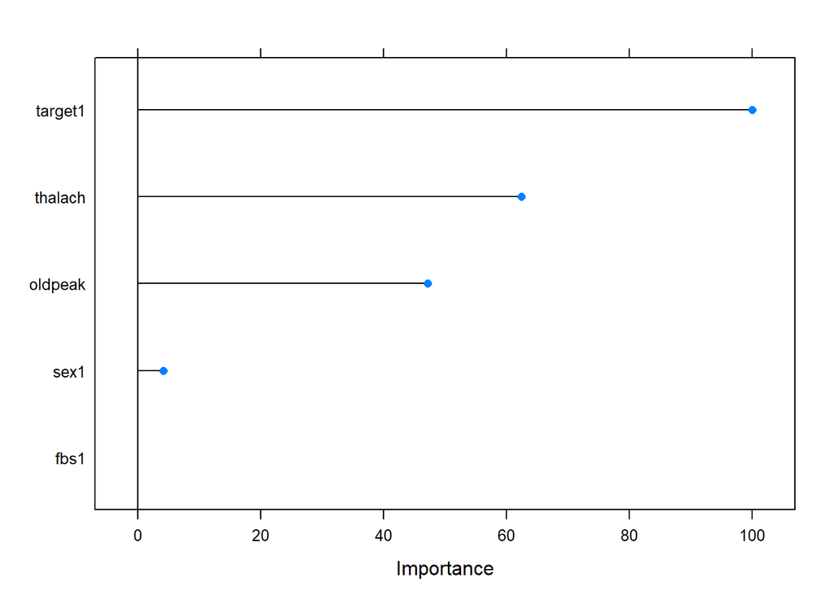

```r
plot(varImp(model_forest))
```

```r
pred<-predict(model_forest,newdata = test)
confusionMatrix(pred,test$cp)
```

```
## Confusion Matrix and Statistics
##
##           Reference
## Prediction no mod sev
##        no  22   6   3
##        mod  4  11   6
##        sev  2   0   1
##
## Overall Statistics
##
##                Accuracy : 0.6182
##                  95% CI : (0.4773, 0.7459)
##     No Information Rate : 0.5091
##     P-Value [Acc > NIR] : 0.06848
##
##                   Kappa : 0.3475
##
##  Mcnemar's Test P-Value : 0.08580
##
## Statistics by Class:
##
##                      Class: no Class: mod Class: sev
## Sensitivity             0.7857     0.6471    0.10000
## Specificity             0.6667     0.7368    0.95556
## Pos Pred Value          0.7097     0.5238    0.33333
## Neg Pred Value          0.7500     0.8235    0.82692
## Prevalence              0.5091     0.3091    0.18182
## Detection Rate          0.4000     0.2000    0.01818
## Detection Prevalence    0.5636     0.3818    0.05455
## Balanced Accuracy       0.7262     0.6920    0.52778
```

with this model the accuracy rate is 61.82%

## Cumulative probability model

For this model we need the **VGAM** package.

```r
library(VGAM)
set.seed(1234)
model_vgam<-train(cp~.-age-trestbps-chol,
                                            data=train,
                                            method="vglmCumulative",
                                            trace=FALSE)
```

```r
model_vgam
```

```
## Cumulative Probability Model for Ordinal Data
##
## 225 samples
##   8 predictor
##   3 classes: 'no', 'mod', 'sev'
##
## No pre-processing
## Resampling: Bootstrapped (25 reps)
## Summary of sample sizes: 225, 225, 225, 225, 225, 225, ...
## Resampling results across tuning parameters:
##
##   parallel  link     Accuracy   Kappa
##   FALSE     logit    0.5934870  0.3230918
##   FALSE     probit   0.5908200  0.3190925
##   FALSE     cloglog  0.5863403  0.3148374
##   FALSE     cauchit  0.5973088  0.3198310
##   FALSE     logc           NaN        NaN
##    TRUE     logit    0.5871965  0.3047080
##    TRUE     probit   0.5792635  0.2909696
##    TRUE     cloglog  0.5564699  0.2611301
##    TRUE     cauchit  0.5876136  0.3074172
##    TRUE     logc           NaN        NaN
##
## Accuracy was used to select the optimal model using the largest value.
## The final values used for the model were parallel = FALSE and link = cauchit.
```

the best model is obtaind when the argument **parallel** is FALSE and **link** is **cauchit** which is the tangent function .

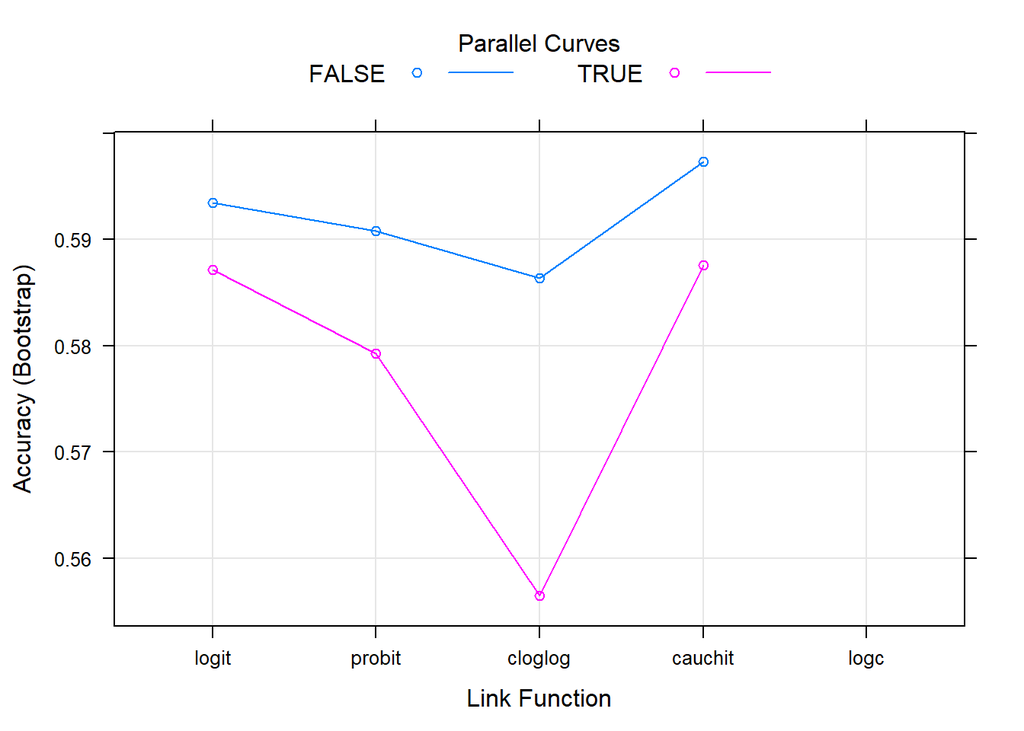

```r
plot(model_vgam)
```

```r
model_vgam$finalModel
```

```
##
## Call:
## VGAM::vglm(formula = .outcome ~ ., family = VGAM::cumulative(link = "cauchit",
##     parallel = FALSE), data = dat, weights = wts)
##
##
## Coefficients:
## (Intercept):1 (Intercept):2        sex1:1        sex1:2        fbs1:1
##    4.40655612    5.69536603   -0.21180009   -0.70457767   -0.46794663
##        fbs1:2     thalach:1     thalach:2     oldpeak:1     oldpeak:2
##    0.54050105   -0.02168820   -0.01537947    0.17506311    0.95502284
##     target1:1     target1:2
##   -1.85369987   -2.25232740
##
## Degrees of Freedom: 450 Total; 438 Residual
## Residual deviance: 372.5886
## Log-likelihood: -186.2943
```

```r
pred<-predict(model_vgam,newdata = test)
confusionMatrix(pred,test$cp)
```

```
## Confusion Matrix and Statistics
##
##           Reference
## Prediction no mod sev
##        no  23   5   2
##        mod  3  10   4
##        sev  2   2   4
##
## Overall Statistics
##
##                Accuracy : 0.6727
##                  95% CI : (0.5329, 0.7932)
##     No Information Rate : 0.5091
##     P-Value [Acc > NIR] : 0.0104
##
##                   Kappa : 0.4548
##
##  Mcnemar's Test P-Value : 0.7610
##
## Statistics by Class:
##
##                      Class: no Class: mod Class: sev
## Sensitivity             0.8214     0.5882    0.40000
## Specificity             0.7407     0.8158    0.91111
## Pos Pred Value          0.7667     0.5882    0.50000
## Neg Pred Value          0.8000     0.8158    0.87234
## Prevalence              0.5091     0.3091    0.18182
## Detection Rate          0.4182     0.1818    0.07273
## Detection Prevalence    0.5455     0.3091    0.14545
## Balanced Accuracy       0.7811     0.7020    0.65556
```

We have now a good accuracy rate which is about 67.27%

## Compare models

We can conmpare between the above models using **resample** caret function.

```r
models_eval<-resamples(list(logit=model_logistic,
                            caret=model_cart,
                            forest=model_forest,
                            vgam=model_vgam))
summary(models_eval)
```

```
##
## Call:
## summary.resamples(object = models_eval)
##
## Models: logit, caret, forest, vgam
## Number of resamples: 25
##
## Accuracy
##             Min.   1st Qu.    Median      Mean   3rd Qu.      Max. NA's
## logit  0.5308642 0.5494505 0.5783133 0.5871965 0.6144578 0.7179487    0
## caret  0.4939759 0.5652174 0.5974026 0.5959006 0.6190476 0.6835443    0
## forest 0.4756098 0.5434783 0.5662651 0.5667161 0.5952381 0.6428571    0
## vgam   0.5487805 0.5727352 0.5863200 0.5973088 0.5970310 0.6923077   13
##
## Kappa
##             Min.   1st Qu.    Median      Mean   3rd Qu.      Max. NA's
## logit  0.1876042 0.2515213 0.2913140 0.3047080 0.3620650 0.5148431    0
## caret  0.1801505 0.2870267 0.3388889 0.3239138 0.3493101 0.4578313    0
## forest 0.1364829 0.2257417 0.2894737 0.2755149 0.3170086 0.3880525    0
## vgam   0.2361531 0.2872552 0.3063328 0.3198310 0.3273909 0.4821577   13
```

Using the mean of the accuracy rate we can say that **vgam** model is the best model for these data with 59.73% for the training set and with 67.27% for the test set as we have obtained.

we can plot these model.

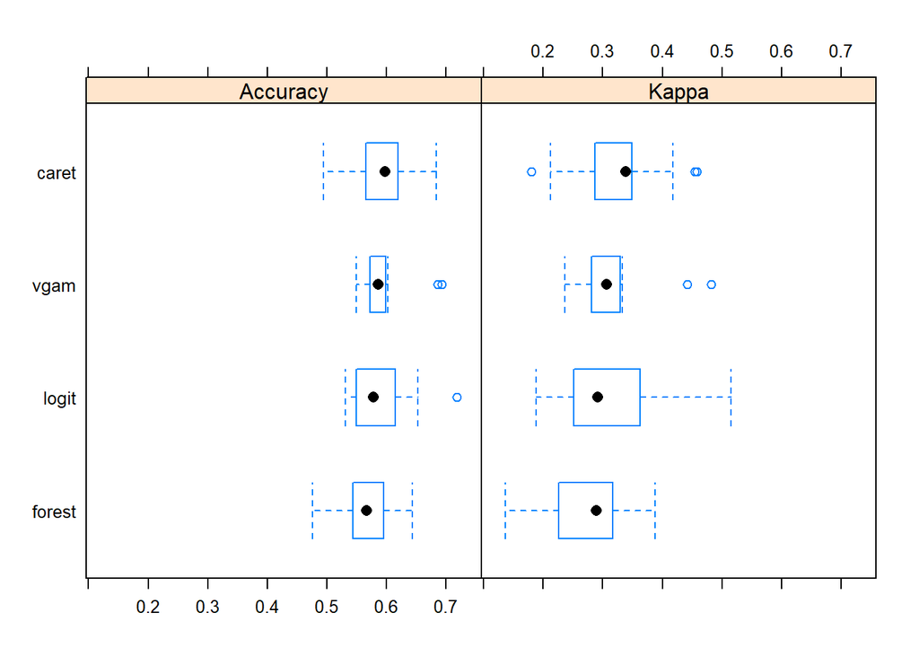

```r
bwplot(models_eval)
```